# Simple Implementation of Pair Trading on FX

## Contents

- Choose Pairs
- Build Different Strategies
- Visualizing Signals from Pair Trading
- Basic Strategy
- Reinforcement Strategy

```python
import pandas as pd
import numpy as np
from math import isnan
import matplotlib.pyplot as plt
from scipy import stats
from scipy.cluster import hierarchy as hc
from statsmodels.tsa.stattools import adfuller
from sklearn.cluster import KMeans
```

# Mean reversion with Norwegian Kroner.

Download the 18 currencies from the WRDS. Make sure the full dataset contains the all the currencies with the selected time period.

```python
# Load the data set
df = pd.read_csv('3ffde2c6dfdb61c2.csv')
df_oil = pd.read_csv('wti_daily.csv')
```

```python
# 2306 obs with 18 currencies and 1 index column
df.shape
df.tail()
```

|  | date | exalus | excaus | exdnus | exhkus | exjpus | exkous | exmaus | exmxus | exnzus | exnous | exsius | exsfus | exsdus | exszus | extaus | exthus | exukus | exeuus |
| --- | --- | --- | --- | --- | --- | --- | --- | --- | --- | --- | --- | --- | --- | --- | --- | --- | --- | --- | --- |
| 2301 | 10/29/2018 | 1.4136 | 1.3129 | 6.5511 | 7.8433 | 112.49 | 1139.81 | 4.178 | 19.761 | 1.5312 | 8.3711 | 1.3826 | 14.5225 | 9.1278 | 1.0006 | 30.96 | 33.22 | 0.7808 | 0.8780 |
| 2302 | 10/30/2018 | 1.4061 | 1.3133 | 6.5659 | 7.8429 | 112.76 | 1137.68 | 4.180 | 19.987 | 1.5239 | 8.3962 | 1.3841 | 14.6225 | 9.1567 | 1.0046 | 30.93 | 33.26 | 0.7855 | 0.8800 |
| 2303 | 10/31/2018 | 1.4104 | 1.3129 | 6.5832 | 7.8393 | 112.86 | 1140.78 | 4.183 | 20.255 | 1.5314 | 8.4100 | 1.3845 | 14.7600 | 9.1462 | 1.0057 | 30.94 | 33.10 | 0.7825 | 0.8825 |
| 2304 | 11/01/2018 | 1.3910 | 1.3108 | 6.5841 | 7.8365 | 112.79 | 1126.19 | 4.177 | 20.133 | 1.5056 | 8.4100 | 1.3765 | 14.5050 | 9.1462 | 1.0033 | 30.75 | 32.93 | 0.7708 | 0.8775 |
| 2305 | 11/02/2018 | 1.3891 | 1.3108 | 6.5564 | 7.8205 | 113.09 | 1117.72 | 4.160 | 20.045 | 1.5026 | 8.3721 | 1.3741 | 14.3800 | 9.0777 | 1.0036 | 30.57 | 32.85 | 0.7713 | 0.8789 |

## Is the Series Stationary?

#### Use the notation `NOK`, when operating on Norwegian kroner, and let `lNOK` mean `log(NOK)`. Investigate using plots and the DF test whether the $NOK$ is stationary. Use your knowledge of world events to give at leat one explanation of your finding.

```python
# Drop NA data
curr2 = df.dropna(axis=0)
oil2 = df_oil.dropna(axis=0)
currnames = ["Date","AUD","CAD","DKK","HKD","JPY","KRW","MYR","MNX","NZD","NOK","SGD","SEK","ZAR","CHF","TWD","THB","GBP","EUR"]
currnames1 = ["Date","Oil"]
type(curr2)
curr2= curr2.reset_index(drop=True) # Reset the index becuase there are missing 0, 11 and so on....
```

```python
curr2.columns = currnames
oil2.columns = currnames1
curr2.shape, oil2.shape
```

```
((2217, 19), (2227, 2))
```

```python
# Take Log
lcurr = curr2.drop('Date',axis=1)
lcurr = np.log(lcurr)
dlcurr = lcurr.diff(periods=2).dropna(axis=0)
```

```python
# ADF test
adf = adfuller(curr2["NOK"])
print('p-value is:%f' %adf[1])
print('ADF Statistic:%f' %adf[0])
```

```
p-value is:0.793805
ADF Statistic:-0.882116
```

From the knowledge of the world event, Norway Kroner has close relationship with the oil price now that Norway economy is heavily dependent on oil export. If we look into the oil price data as below, We can clearly see that the oil price has a negative relationship with Norwegian kroner. And **it is well known that the price of oil is not stationary and its volatility has a heteroskedasticity property.** The oil price went down significantly since a June 2014 to mid 2016, where the price was 115 USD a barrel around june and dropped to below 40 USD at the lowest. On the contrary, we can see the NOK price move in an opposite way with very high correlation. This means that the NOK is very likeley to follow non-stationary process with hetergoskedasticity property.

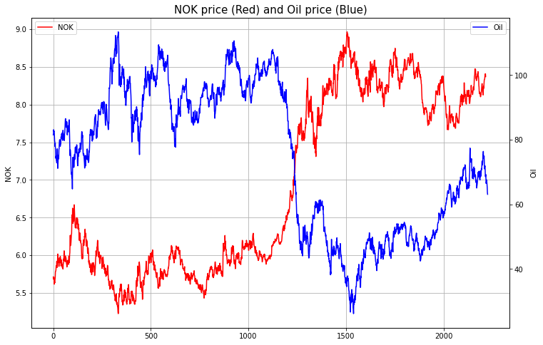

```python
# lets check with the oil price

%matplotlib inline
#plt.rcParams['figure.figsize'] = (10,6)
fig = plt.figure(figsize=(12, 8))
ax = fig.add_subplot(111)
ax.plot(curr2["NOK"], '-r', label = 'NOK')
ax2 = ax.twinx()
ax2.plot(oil2["Oil"], '-b', label = 'Oil')
ax.legend(loc='upper left')
ax2.legend(loc='upper right')
ax.grid()
ax.set_ylabel("NOK")
ax2.set_ylabel("Oil")
#ax2.set_ylim(0, 35)
#ax.set_ylim(-20,100)
plt.title("NOK price (Red) and Oil price (Blue)",fontsize='15')
plt.show()
```

## Correlation from other Currencies

#### Find up to four currencies that well predict the log NOK in terms of least squares regression. you can argue from a combination of statistics and your knowledge of world events which currencies you would like to include.

There are some ways to see which currency predicts the log NOK well.

**1) Reduce the dataset with the currencies of the countries that are geographically close to Norway: Countries in Europe**

- DKK, SEK, CHF, GBP, EUR

**2) Consider country vulnerable to Oil price, Check the top 15 oil exporter countries (source: WTEx)** Curreny of oil import countries such as Korea and Japan are also sensitive to oil price but not as much as the oil exporter countries where their economy is heavily dependent on its price

- (4) Canada: USD 54 billion
- (11) Norway: USD 25.9 billion
- (13) United States: USD 21.8 billion
- (14) Mexico: USD 19.9 billion
- (15) United Kingdom: USD 19 billion

$\Rightarrow$ I will take Canada that is above the Norway

**3) Draw a Dendrogram for the reduced sets as in the HW2**

- Reduce set of currency would be 'CAD','DKK','SEK','CHF','GBP','EUR'

```python
#1,2 - Run a simple multiple regression on countries in EU and NA

import statsmodels.api as sm
lcurr['const'] = 1
reg1 = sm.OLS(endog=lcurr['NOK'], exog=lcurr[['const', 'CAD','DKK','SEK','CHF','GBP','EUR']], missing='drop')
#type(reg1)
results = reg1.fit()
#type(results)
print(results.summary())
```

```
                            OLS Regression Results
==============================================================================
Dep. Variable:                    NOK   R-squared:                       0.983
Model:                            OLS   Adj. R-squared:                  0.983
Method:                 Least Squares   F-statistic:                 2.099e+04
Date:                Thu, 25 Mar 2021   Prob (F-statistic):               0.00
Time:                        13:37:19   Log-Likelihood:                 5302.2
No. Observations:                2217   AIC:                        -1.059e+04
Df Residuals:                    2210   BIC:                        -1.055e+04
Df Model:                           6
Covariance Type:            nonrobust
==============================================================================
                 coef    std err          t      P>|t|      [0.025      0.975]
------------------------------------------------------------------------------
const          5.8795      0.865      6.796      0.000       4.183       7.576
CAD            1.0678      0.015     73.217      0.000       1.039       1.096
DKK           -1.9700      0.433     -4.551      0.000      -2.819      -1.121
SEK           -0.0113      0.005     -2.084      0.037      -0.022      -0.001
CHF            0.0859      0.010      8.228      0.000       0.065       0.106
GBP            0.0666      0.010      6.694      0.000       0.047       0.086
EUR            2.3660      0.431      5.484      0.000       1.520       3.212
==============================================================================
Omnibus:                       19.497   Durbin-Watson:                   0.062
Prob(Omnibus):                  0.000   Jarque-Bera (JB):               13.057
Skew:                          -0.010   Prob(JB):                      0.00146
Kurtosis:                       2.625   Cond. No.                     7.10e+03
==============================================================================

Notes:
[1] Standard Errors assume that the covariance matrix of the errors is correctly specified.
[2] The condition number is large, 7.1e+03. This might indicate that there are
strong multicollinearity or other numerical problems.
```

```python
reg2 = sm.OLS(endog=lcurr['CAD'], exog=lcurr[['const','SEK']], missing='drop')
#type(reg2)
results2 = reg2.fit()
#type(results)
print(results2.summary())
```

```
                            OLS Regression Results
==============================================================================
Dep. Variable:                    CAD   R-squared:                       0.870
Model:                            OLS   Adj. R-squared:                  0.870
Method:                 Least Squares   F-statistic:                 1.486e+04
Date:                Thu, 25 Mar 2021   Prob (F-statistic):               0.00
Time:                        13:37:19   Log-Likelihood:                 3794.1
No. Observations:                2217   AIC:                            -7584.
Df Residuals:                    2215   BIC:                            -7573.
Df Model:                           1
Covariance Type:            nonrobust
==============================================================================
                 coef    std err          t      P>|t|      [0.025      0.975]
------------------------------------------------------------------------------
const         -0.8772      0.008   -105.539      0.000      -0.894      -0.861
SEK            0.4302      0.004    121.893      0.000       0.423       0.437
==============================================================================
Omnibus:                      661.819   Durbin-Watson:                   0.011
Prob(Omnibus):                  0.000   Jarque-Bera (JB):              118.614
Skew:                          -0.214   Prob(JB):                     1.75e-26
Kurtosis:                       1.951   Cond. No.                         24.8
==============================================================================

Notes:
[1] Standard Errors assume that the covariance matrix of the errors is correctly specified.
```

```python
basket = lcurr[['CAD','DKK','NOK','SEK','CHF','GBP','EUR']]
```

```python
type(basket)
```

```
pandas.core.frame.DataFrame
```

```
          CAD       DKK       NOK       SEK       CHF       GBP       EUR
CAD  1.000000  0.891192  0.982899  0.932878  0.381407  0.759749  0.889944
DKK  0.891192  1.000000  0.929546  0.823270  0.501388  0.750276  0.999896
NOK  0.982899  0.929546  1.000000  0.906064  0.449417  0.791348  0.929113
SEK  0.932878  0.823270  0.906064  1.000000  0.241868  0.657711  0.820837
CHF  0.381407  0.501388  0.449417  0.241868  1.000000  0.500130  0.504506
GBP  0.759749  0.750276  0.791348  0.657711  0.500130  1.000000  0.754385
EUR  0.889944  0.999896  0.929113  0.820837  0.504506  0.754385  1.000000
```

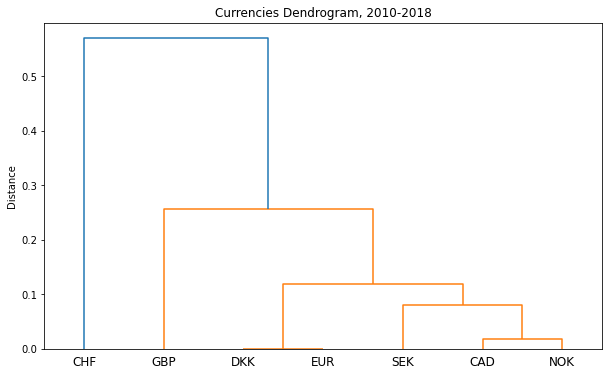

```python
#3 - Dendogram
%matplotlib inline
Corr = basket.corr()
print(Corr)
z = hc.linkage(basket.values.T, method='average',metric='correlation')
plt.figure(figsize=(10, 6))
plt.title('Currencies Dendrogram, 2010-2018', fontsize=12)
plt.ylabel('Distance')
den = hc.dendrogram(z,labels=basket.columns)
plt.show()
```

A dendrogram is a branching diagram that represents the relationships of similarity among a group of entities. Note that the Danish Krone is part of the European Exchange Rate Mechanism, aimed at reducing exchange rate volatility among EU nations. It pegs to the Euro at a ratio of 7.46 krone to one euro, and is required to stay within 2.25% of that level.

Two closest clusters are joined into the same cluster. As it is showns in the dendogram, besides the pair of DKK and EUR, **CAD and NOK** are more similar than others, which has 0.98 correlation coefficient. This is mainly because they are both very vulnerable to oil price as oil exporter. The next currency that shows close relationship to **NOK is SEK**, which is reasonble in that they share the border and their economy somewhat depend on natural resources. **Moreover**, since we know from the HW3 that CAD has a lower correlation with other currencies (DKK,HKD,SGD,CHF,EUR), we can safely say that the two most relavant currency to predict lNOK is **CAD and SEK**. And the next two are DKK and EUR.

#### Four Currencies:

Two most relevant: (CAD, SEK)  
Next two relevelant: (DKK, EUR)

## Simply Trying Regression to Generate Signal

Suppose that we trade NOK with CAD and SEK. This gives rise to a regression

$lNOK=\gamma_1 lCAD + \gamma_2 lSEK + \epsilon$

We wish to implement a strategy along the lines of Question 2(b) of HW3. We trade with USD as basis currency, and we short the NOK when $\epsilon$ reaches a comparatively high value $highC$, and we go long the NOK when $\epsilon$ reaches a comparatively low value $lowC$.  
Describe three strategies for this situation.

(i) The basic strategy

(ii) The reinforcing strategy

(iii) The reinforcing with a limit on the number of positions.

#### Simple Regression

```python
# Lets do the regression first
reg3 = sm.OLS(endog=lcurr['NOK'], exog=lcurr[['CAD','SEK']], missing='drop')
results3 = reg3.fit()
print(results3.summary())
#dir(results3) check what options we have
print("parameters: ", results3.params)
reg3_resid = results3.resid
```

```
                                 OLS Regression Results
=======================================================================================
Dep. Variable:                    NOK   R-squared (uncentered):                   0.998
Model:                            OLS   Adj. R-squared (uncentered):              0.998
Method:                 Least Squares   F-statistic:                          5.094e+05
Date:                Thu, 25 Mar 2021   Prob (F-statistic):                        0.00
Time:                        13:37:20   Log-Likelihood:                          2198.7
No. Observations:                2217   AIC:                                     -4393.
Df Residuals:                    2215   BIC:                                     -4382.
Df Model:                           2
Covariance Type:            nonrobust
==============================================================================
                 coef    std err          t      P>|t|      [0.025      0.975]
------------------------------------------------------------------------------
CAD           -0.2891      0.018    -16.266      0.000      -0.324      -0.254
SEK            0.8345      0.001    623.031      0.000       0.832       0.837
==============================================================================
Omnibus:                      117.335   Durbin-Watson:                   0.007
Prob(Omnibus):                  0.000   Jarque-Bera (JB):               46.094
Skew:                          -0.031   Prob(JB):                     9.79e-11
Kurtosis:                       2.296   Cond. No.                         22.0
==============================================================================

Notes:
[1] R² is computed without centering (uncentered) since the model does not contain a constant.
[2] Standard Errors assume that the covariance matrix of the errors is correctly specified.
parameters:  CAD   -0.289071
SEK    0.834527
dtype: float64
```

$spread=lNOK-\gamma_{CAD}lCAD-\gamma_{SEK}lSEK=\epsilon$

- When $\epsilon$ is > 0, $ lNOK > \gamma_{CAD}\cdot lCAD-\gamma_{SEK} \cdot lSEK$
- When $\epsilon$ is < 0, $ lNOK < \gamma_{CAD}\cdot lCAD-\gamma_{SEK} \cdot lSEK$

#### i) Basic Strategy (for the first time $\epsilon$ > highC & $\epsilon$ < lowC)

- Basic strategy is basic in that we only take position when it first cross the threshold line and do nothing when it stay above/below the higher/lower threshold.
- **At the first time $\epsilon$ < lowC $\Rightarrow$ Long $\frac{1}{p_{NOK}}$ unit of NOK, Short $\frac{\gamma_{SEK}}{p_{SEK}}$ unit of SEK, Long $\frac{\gamma_{CAD}}{p_{CAD}}$ CAD**
- **AT the first time $\epsilon$ > highC $\Rightarrow$ Short $\frac{1}{p_{NOK}}$ unit of NOK, Long $\frac{\gamma_{SEK}}{p_{SEK}}$ unit of SEK, Short $\frac{\gamma_{CAD}}{p_{CAD}}$ CAD (after liquidating)**

#### ii) Reinforcement Strategy

- Reinforcement strategy takes position whenever satisfying the criteria and stay its position unless it crosses back to the threshold.
- **Whenever $\epsilon$ < lowC $\Rightarrow$ Long $\frac{1}{p_{NOK}}$ unit of NOK, Short $\frac{\gamma_{SEK}}{p_{SEK}}$ unit of SEK, Long $\frac{\gamma_{CAD}}{p_{CAD}}$ CAD**
- **Whenever $\epsilon$ > highC $\Rightarrow$ Short $\frac{1}{p_{NOK}}$ unit of NOK, Long $\frac{\gamma_{SEK}}{p_{SEK}}$ unit of SEK, Short $\frac{\gamma_{CAD}}{p_{CAD}}$ CAD (after liquidating)**

#### iii) Reinforce with limit on the number of open positions

- This strategy takes position whenever satisfying the criteria and stay its position for limited number of time, not always as in (ii)
- **For certain number of times when $\epsilon$ < lowC $\Rightarrow$ Long $\frac{1}{p_{NOK}}$ unit of NOK, Short $\frac{\gamma_{SEK}}{p_{SEK}}$ unit of SEK, Long $\frac{\gamma_{CAD}}{p_{CAD}}$ CAD**
- **For certain number of times when $\epsilon$ > highC $\Rightarrow$ Short $\frac{1}{p_{NOK}}$ unit of NOK, Long $\frac{\gamma_{SEK}}{p_{SEK}}$ unit of SEK, Short $\frac{\gamma_{CAD}}{p_{CAD}}$ CAD (after liquidating)**

## Mean-SD V.S. Quantile

Inspect the time series plot of the $\epsilon$ as well as the histogram. Determine whether you prefer to select the threshold criteria between (1) mean-sd and (2) quantile based on the given information

$\Rightarrow$ **If the residual is normally distributed, I prefer to use the first one with mean&sd. If not, I would prefer to use the empricial cdf at 35, 65 percentile to decide the low/high C.**

```python
reg3_resid
```

```
0       0.094725
1       0.091131
2       0.086889
3       0.077719
4       0.082584
          ...
2212   -0.029461
2213   -0.032106
2214   -0.038362
2215   -0.024281
2216   -0.021575
Length: 2217, dtype: float64
```

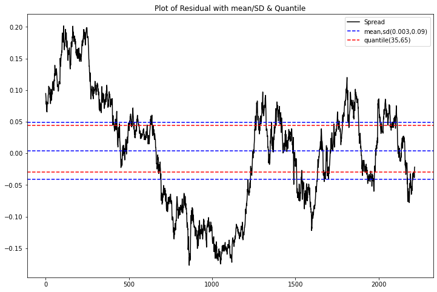

```python
%matplotlib inline
plt.figure(figsize=(12, 8))
plt.plot(reg3_resid,color='black',label='Spread')
plt.axhline(reg3_resid.mean(), color="blue", linestyle='--')
plt.axhline(reg3_resid.mean()+reg3_resid.std()*0.5, color="blue",linestyle='--',label= 'mean,sd(0.003,0.09)' )
plt.axhline(reg3_resid.mean()-reg3_resid.std()*0.5, color="blue",linestyle='--')
plt.axhline(np.quantile(reg3_resid,0.35),color='red',label='quantile(35,65)',linestyle='--')
plt.axhline(np.quantile(reg3_resid,0.65),color='red',linestyle='--')
plt.legend(loc='upper right')
plt.title("Plot of Residual with mean/SD & Quantile", fontsize=12)
```

```python
reg3_resid.shape, reg3_resid.std(), reg3_resid.mean()
```

```
((2217,), 0.08969028666465001, 0.003838785373159017)
```

[output not shown]

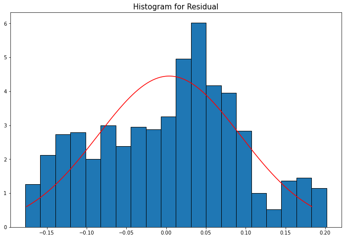

```python
# Histogram
%matplotlib inline
from scipy.stats import norm
mu = reg3_resid.mean()
sigma = reg3_resid.std()
x = np.linspace(mu - 2*sigma, mu + 2*sigma, 200)
plt.figure(figsize=(12, 8))
plt.hist(reg3_resid, 20, edgecolor='black', density=True)
plt.plot(x,norm.pdf(x, mu, sigma),color="Red",label='$\mu$=0, $\sigma$=0.09')
plt.title('Histogram for Residual', fontsize=15)
plt.plot()
```

The histogram and the fitted normal pdf clearly shows that the residual is not normally distributed. We can also try QQ plot

## Try QQ Plot

Explain how the information in the time series plot and the histogram may be insufficient to decide highC and lowC.

It is insufficient in two ways.

**1) By relying on the plot and histogram, we can't decide whether it is normally distributed or not. Instead, we can try two other common statistical tests that are QQ plot and Kolmogorov–Smirnov test as below**

**2) We can not guarantee stationarity (mean reverting) that we want to have in order to make pair trading work properly. Need to do ADF test for residuals**

```
((array([-3.42043786, -3.17130311, -3.03322659, ...,  3.03322659,
          3.17130311,  3.42043786]),
  array([-0.17709856, -0.17494621, -0.17473207, ...,  0.19900091,
          0.20125771,  0.20170659])),
 (0.08879084091083814, 0.003838785373158976, 0.9888311932227847))
```

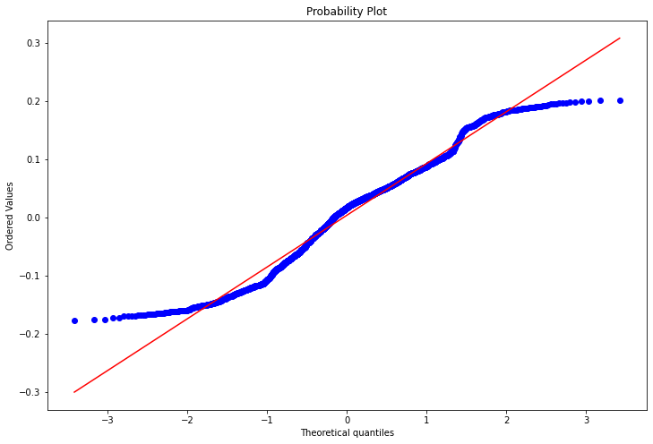

```python
from scipy.stats import probplot
plt.figure(figsize = (12,8))
probplot(reg3_resid, plot=plt)
```

QQ plot shows that residual doesn't follows normal distribution.

**The Kolmogorov–Smirnov tests**  
If a sample distribution fits a cumulative distribution function (CDF) of are referenced distribution. Null hypothesis for our sample is that the distribution is identical to the normal distribution. If p < .05 we can reject the null, and conclude our sample distribution is not identical to a normal distribution. **In this case, we have p-value less than 0.05, I prefer to use the quantile one.**

```python
print(stats.kstest(reg3_resid, 'norm'))
print('With critically low p-value, it is not distributed as normal')
```

```
KstestResult(statistic=0.43027715091844687, pvalue=0.0)
With critically low p-value, it is not distributed as normal
```

**ADF test on Residual**

```python
# ADF test
adf = adfuller(reg3_resid)
print('p-value is:%f' %adf[1])
print('ADF Statistic:%f' %adf[0])
```

```
p-value is:0.329391
ADF Statistic:-1.905685
```

**Ideally, P-value should be less than 0.05. Small p-values suggest the data is stationary. Since we have high p-value, which implies that the residual is not stationary.**

## Visualizing Signals from Pair Trading

Write a code to compute the turning points for the first reinforcing strategy.

- **Whenever $\epsilon$ < lowC $\Rightarrow$ Long $\frac{1}{p_{NOK}}$ unit of NOK, Short $\frac{\gamma_{SEK}}{p_{SEK}}$ unit of SEK, Long $\frac{\gamma_{CAD}}{p_{CAD}}$ CAD**
- **Whenever $\epsilon$ > highC $\Rightarrow$ Short $\frac{1}{p_{NOK}}$ unit of NOK, Long $\frac{\gamma_{SEK}}{p_{SEK}}$ unit of SEK, Short $\frac{\gamma_{CAD}}{p_{CAD}}$ CAD (after liquidating)**

#### Visualizing the buy/sell signal on the spread

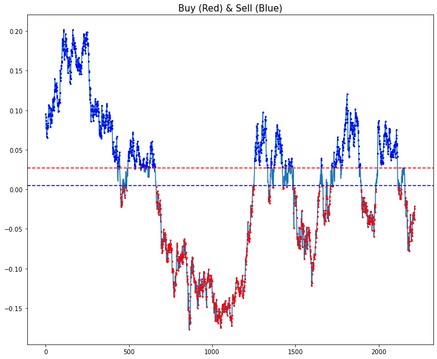

```python
%matplotlib inline
plt.figure(figsize=(12,10))
buy = reg3_resid.copy()
sell = reg3_resid.copy()
sell[reg3_resid >= np.quantile(reg3_resid,0.45)] = np.nan
buy[reg3_resid <= np.quantile(reg3_resid,0.55)] = np.nan

reg3_resid.plot()
buy.plot(color='b', linestyle='None', marker='o', markersize = 2)
sell.plot(color='r', linestyle='None',marker='o', markersize = 2)
plt.title('Buy (Red) & Sell (Blue)',fontsize='15')
plt.axhline(np.quantile(reg3_resid,0.45),color="b",label='quantile',linestyle='--')
plt.axhline(np.quantile(reg3_resid,0.55),color="r",linestyle='--')
plt.show()
```

## Visualizing which asset to buy / sell?

```python
signal = reg3_resid.copy()
signal[reg3_resid >= np.quantile(reg3_resid,0.45)] = -1
signal[reg3_resid <= np.quantile(reg3_resid,0.55)] = 1

# plot the prices and buy and sell signals from the spread
NOK = curr2['NOK']
SEK = curr2['SEK']
CAD = curr2['CAD']

nok_b_sek_s = np.nan*NOK.copy()
nok_s_sek_b = np.nan*NOK.copy()
nok_b_cad_s = np.nan*NOK.copy()
nok_s_cad_b = np.nan*NOK.copy()
```

[figure not shown]

```python
# With Buy signal,Long NOK, Short SEK, Long CAD
nok_b_sek_s[signal==1] = NOK[signal==1]
nok_b_sek_s[signal==-1] = SEK[signal==-1]
nok_s_sek_b[signal==-1] = NOK[signal==-1]
nok_s_sek_b[signal==1] = SEK[signal==1]
nok_b_cad_s[signal==1] = CAD[signal==1]
nok_s_cad_b[signal==-1] = CAD[signal==-1]

textstr = '\n'.join((
    'Red: Buy Signal',
    'Blue: Sell Signal'))
%matplotlib inline

plt.figure(figsize=(12,10))
NOK.plot(color='black')
SEK.plot(color='grey')
CAD.plot(color='silver')
nok_b_sek_s.plot(color='red', linestyle='None', marker='^', markersize=1)
nok_s_sek_b.plot(color='blue', linestyle='None', marker='^', markersize=1)
nok_b_cad_s.plot(color='red', linestyle='None', marker='^', markersize=1)
nok_s_cad_b.plot(color='blue', linestyle='None', marker='^', markersize=1)
x1,x2,y1,y2 = plt.axis()
plt.legend(['SEK(Upper)','NOK(Mid)','CAD(Below)'])
plt.title('Signal Displayed on NOK,SEK,CAD Price', fontsize='15')
plt.text(-0.05, 0.8, textstr, transform=ax.transAxes, fontsize=14,
        verticalalignment='top')
plt.show()
```

**Let’s see what kind of profits this signal can generate. We write a simple backtester**

- buy 1 NOK, gamma_CAD unit CAD, and sell gamma_SEK unit SEK when spread is low
- sell 1 NOK, gamma_CAD unit CAD, and buy gamma_SEK unit SEK when spread is high

Then calculate Profit & Loss of these trades.

```python
# Define variables
gamma = results3.params
spread = lcurr['NOK'] - gamma.SEK*lcurr['SEK'] - gamma.CAD*lcurr['CAD']
highC = np.quantile(spread,0.55)
lowC = np.quantile(spread,0.45)
print(gamma.CAD, gamma.SEK)
print(highC, lowC)

spread.shape
#plt.plot(spread)
```

```
-0.28907111668640795 0.8345267568594674
0.027005660617713804 0.004655831974022145
```

```
(2217,)
```

## Basic Strategy

On what days do you trade? (between 1:2217)  
What is your profit and loss?  
What is your average holding time (in days)  
You can assume zero transaction cost.

```python
b = results3.params
spread = lcurr['NOK'] - gamma.SEK*lcurr['SEK'] - gamma.CAD*lcurr['CAD']
nok = curr2['NOK']
sek = curr2['SEK']
cad = curr2['CAD']
lowC = np.quantile(spread,0.45)
highC = np.quantile(spread,0.55)
low_ind = spread[spread<lowC].index
high_ind = spread[spread>highC].index
h = high_ind.min()
l = low_ind.min()
```

Position is taken the first time when

- Buy Signal Generated at the first time $\epsilon$ < lowC after $\epsilon$ > highC
  - Long $\frac{1}{p_{NOK}}$ unit of NOK, Short $\frac{\gamma_{SEK}}{p_{SEK}}$ unit of SEK, Long $\frac{\gamma_{CAD}}{p_{CAD}}$ CAD
- Sell Signal Generated at the first time $\epsilon$ > highC happens after $\epsilon$ < lowC
  - Short $\frac{1}{p_{NOK}}$ unit of NOK, Long $\frac{\gamma_{SEK}}{p_{SEK}}$ unit of SEK, Short $\frac{\gamma_{CAD}}{p_{CAD}}$ CAD (after liquidating)

```python
low_list = spread[spread<lowC].index.tolist()
high_list = spread[spread>highC].index.tolist()
trading_ind = np.r_[l].tolist()
```

```python
trading_ind
```

```
[449]
```

```python
nok = curr2['NOK']
sek = curr2['SEK']
cad = curr2['CAD']

lowC = np.quantile(spread,0.45)
highC = np.quantile(spread,0.55)

low_ind = spread[spread<lowC].index
high_ind = spread[spread>highC].index
h = high_ind.min()
l = low_ind.min()

low_list = spread[spread<lowC].index.tolist()
high_list = spread[spread>highC].index.tolist()

trading_ind = np.r_[l].tolist()
```

```python
h,l, len(spread)
```

```
(0, 449, 2217)
```

```python
while True:
    if h > 2217 or l > 2217:
        break
    if h < l:
        if len(set(high_list).intersection(set(np.r_[(l+1):2218]))) == 0:
            break
        else:
            h = min(set(high_list).intersection(set(np.r_[(l+1):2218])))
            trading_ind.append(h)
        print(f' high to low : {h}')
    else:
        if len(set(low_list).intersection(set(np.r_[(h+1):2218]))) == 0:
            break
        else:
            l = min(set(low_list).intersection(set(np.r_[(h+1):2218])))
            trading_ind.append(l)
        print(f' low to high : {l}')
```

```
 high to low : 495
 low to high : 663
 high to low : 1255
 low to high : 1337
 high to low : 1351
 low to high : 1365
 high to low : 1370
 low to high : 1425
 high to low : 1438
 low to high : 1448
 high to low : 1459
 low to high : 1484
 high to low : 1654
 low to high : 1659
 high to low : 1718
 low to high : 1722
 high to low : 1730
 low to high : 1895
 high to low : 1994
 low to high : 2116
 high to low : 2148
 low to high : 2158
```

#### Time when trade happened and Holding Time

```python
np.array(trading_ind), np.diff(trading_ind)
```

```
(array([ 449,  495,  663, 1255, 1337, 1351, 1365, 1370, 1425, 1438, 1448,
        1459, 1484, 1654, 1659, 1718, 1722, 1730, 1895, 1994, 2116, 2148,
        2158]),
 array([ 46, 168, 592,  82,  14,  14,   5,  55,  13,  10,  11,  25, 170,
          5,  59,   4,   8, 165,  99, 122,  32,  10]))
```

# Basic Trading Algorithm

```python
# Trading Algorithm for Basic Strategy
# input x with quantile (ex) Basic([45,55])
def Basic (x):

    lowC = np.quantile(spread,x[0]*0.01)
    highC = np.quantile(spread,x[1]*0.01)

    low_ind = spread[spread<lowC].index
    high_ind = spread[spread>highC].index
    h = high_ind.min()
    l = low_ind.min()

    low_list = spread[spread<lowC].index.tolist()
    high_list = spread[spread>highC].index.tolist()

    trading_ind = np.r_[l].tolist()

    while True:
        if h > 2217 or l > 2217:
            break
        if h < l:
            if len(set(high_list).intersection(set(np.r_[(l+1):2218]))) == 0:
                break
            else:
                h = min(set(high_list).intersection(set(np.r_[(l+1):2218])))
                trading_ind.append(h)
        else:
            if len(set(low_list).intersection(set(np.r_[(h+1):2218]))) == 0:
                break
            else:
                l = min(set(low_list).intersection(set(np.r_[(h+1):2218])))
                trading_ind.append(l)
    money = 1
    signal = 1
    for i in range(len(trading_ind)-1):
            t1 = trading_ind[i]
            t2 = trading_ind[i+1]
            money += signal*(1/nok[t1]*(nok[t2]-nok[t1])
                        -gamma.CAD*(1/cad[t1])*(cad[t2]-cad[t1])
                            -gamma.SEK*(1/sek[t1])*(sek[t2]-sek[t1]))
            signal = -signal
    return money, signal, trading_ind
```

### Basic Strategy with Quantile (45, 55)

```python
%%time
# Example with quantile 45, 55
trading_ind=pd.Series(Basic([45,55])[2])
print("What is the profit/loss?")
print("The profit at the end:", Basic([45,55])[0])
print("Average Holding time:", np.diff(trading_ind).mean())
print("Trade Occurs:", Basic([45,55])[2])
```

```
What is the profit/loss?
The profit at the end: 1.6562357444293907
Average Holding time: 77.68181818181819
Trade Occurs: [449, 495, 663, 1255, 1337, 1351, 1365, 1370, 1425, 1438, 1448, 1459, 1484, 1654, 1659, 1718, 1722, 1730, 1895, 1994, 2116, 2148, 2158]
CPU times: user 56.7 ms, sys: 5.35 ms, total: 62.1 ms
Wall time: 63.2 ms
```

## For the Basic strategy, find the choice of highC and lowC that maximizes the profit.

## Grid Search

```python
max_profit = 0

for low in np.linspace(10, 50, 50):
    for high in np.linspace(50, 90, 50):
        profit = Basic([low,high])[0]
        if profit > max_profit:
            max_profit = profit
            best_params = [low, high]
```

```python
print('Best low quantile:', round(best_params[0], 5))
print('Best high quantile:', round(best_params[1], 5))
print('Maximized Profit:', round(max_profit, 5))
```

```
Best low quantile: 39.38776
Best high quantile: 77.7551
Maximized Profit: 2.02316
```

```python
lowC = np.quantile(spread,0.45)
highC = np.quantile(spread,0.55)

low_ind = spread[spread<lowC].index
high_ind = spread[spread>highC].index
h = high_ind.min()
l = low_ind.min()

low_list = spread[spread<lowC].index.tolist()
high_list = spread[spread>highC].index.tolist()

trading_ind = np.r_[h,l].tolist()
trading_ind

while True:
    if h > 2217 or l > 2217:
        break
    if h < l:
        if len(set(high_list).intersection(set(np.r_[(l+1):2218]))) == 0:
            break
        else:
            h =min(set(high_list).intersection(set(np.r_[(l+1):2218])))
            trading_ind.append(h)
    else:
        if len(set(low_list).intersection(set(np.r_[(h+1):2218]))) == 0:
            break
        else:
            l =min(set(low_list).intersection(set(np.r_[(h+1):2218])))
            trading_ind.append(l)
```

```python
trading_ind
```

```
[0,
 449,
 495,
 663,
 1255,
 1337,
 1351,
 1365,
 1370,
 1425,
 1438,
 1448,
 1459,
 1484,
 1654,
 1659,
 1718,
 1722,
 1730,
 1895,
 1994,
 2116,
 2148,
 2158]
```

# Reinforce Strategy

```python
# Trading Algorithm for Basic Strategy
def Reinforce(x):

    lowC = np.quantile(spread,x[0]*0.01)
    highC = np.quantile(spread,x[1]*0.01)

    low_ind = spread[spread<lowC].index
    high_ind = spread[spread>highC].index
    h = high_ind.min()
    l = low_ind.min()

    low_list = spread[spread<lowC].index.tolist()
    high_list = spread[spread>highC].index.tolist()

    if h > l:
        trading_ind = np.r_[l,h].tolist()
        signal = -1
    else:
        trading_ind = np.r_[h,l].tolist()
        signal = 1

    while True:
        if h > 2217 or l > 2217:
            break
        if h < l:
            if len(set(high_list).intersection(set(np.r_[(l+1):2218]))) == 0:
                break
            else:
                h =min(set(high_list).intersection(set(np.r_[(l+1):2218])))
                trading_ind.append(h)
        else:
            if len(set(low_list).intersection(set(np.r_[(h+1):2218]))) == 0:
                break
            else:
                l =min(set(low_list).intersection(set(np.r_[(h+1):2218])))
                trading_ind.append(l)

    money = 1
    signal = -1
    hold_ind = 0
    trading_points = list()

    for i in range(len(trading_ind)-1):
        t1 = trading_ind[i]
        t2 = trading_ind[i+1]
        if signal > 0:
            trading_duration = set(low_list).intersection(set(np.r_[t1:t2-1]))
            for j in trading_duration:
                money += signal*(1/nok[j]*(nok[t2]-nok[j])
                            -gamma.CAD*(1/cad[j])*(cad[t2]-cad[j])
                                 -gamma.SEK*(1/sek[j])*(sek[t2]-sek[j]))
            trading_points.append(trading_duration)
        else:
            trading_duration = set(high_list).intersection(set(np.r_[t1:t2-1]))
            for j in trading_duration:
                money += signal*(1/nok[j]*(nok[t2]-nok[j])
                        -gamma.CAD*(1/cad[j])*(cad[t2]-cad[j])
                            -gamma.SEK*(1/sek[j])*(sek[t2]-sek[j]))
            trading_points.append(trading_duration)
            hold_ind += len(trading_duration)
        signal = -signal
    return money, signal, trading_points, hold_ind
```

```python
print(f'Average Holding time is {np.diff(np.array(list(set().union(*Reinforce([45,55])[2])))).mean():.2f}')
avg_holding = np.diff(np.array(list(set().union(*Reinforce([45,55])[2])))).mean()
```

```
Average Holding time is 1.11
```

```python
# Example with quantile 45, 55
trading_ind=pd.Series(trading_ind)
print("What is the profit/loss?")
print("The profit at the end:", Reinforce([45,55])[0])
print("Average Holding time (in Days):" + f'{avg_holding:.2f}')
print("Number of Trade Occurs:", len(set().union(*Reinforce([45,55])[2])))
```

```
What is the profit/loss?
The profit at the end: 206.33369779226666
Average Holding time (in Days):1.11
Number of Trade Occurs: 1937
```

### For the reinforcing strategy, find the choice of highC and lowC that maximizes the profit.

In order to do that, I will implement the different combinations of quantile numbers to get the maximized profit.

```python
%%time
max_profit = 0

for low in np.linspace(10, 50, 20):
    for high in np.linspace(50, 90, 20):
        profit = Reinforce([low,high])[0]
        if profit > max_profit:
            max_profit = profit
            best_params = [low, high]
```

```
CPU times: user 23.9 s, sys: 80.7 ms, total: 24 s
Wall time: 24.1 s
```

```python
print('Best low quantile:', round(best_params[0], 5))
print('Best high quantile:', round(best_params[1], 5))
print('Maximized Profit:', round(max_profit, 5))
```

```
Best low quantile: 28.94737
Best high quantile: 54.21053
Maximized Profit: 274.13931
```